# Intro to bulk RNA-seq supplemental info

Jaclyn Taroni for CCDL

2020-06-26

## Introduction

This notebook is designed to address questions that came up in the Intro to Bulk RNA-seq module during CCDL training.

## Project organization

We were asked to create a diagram that illustrates the relationship between different files used throughout the RNA-seq module. Here’s the diagram that illustrates the RNA-seq pipeline again.

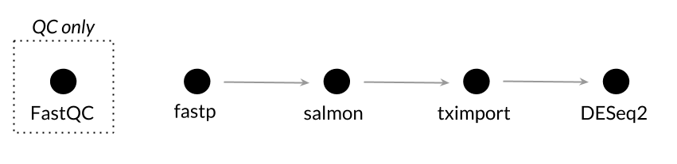

```r
pipeline_overview <- file.path("diagrams", "rna-seq_1.png")
knitr::include_graphics(pipeline_overview)
```

The diagram below is a simplifed version of a file tree. Directories or folders are shown in bold blue font; files are shown in black font.

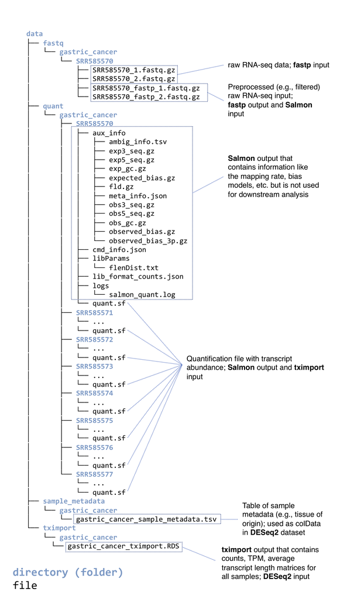

```r
gastric_cancer_structure <- file.path("diagrams", "gastric_cancer_structure.png")
knitr::include_graphics(gastric_cancer_structure)
```

Each file or data *type* (FASTQ, quant, metadata, and tximport) is stored in its own folder within `data`. Each dataset/experiment is stored in a separate directory within the directory that indicates the data type.

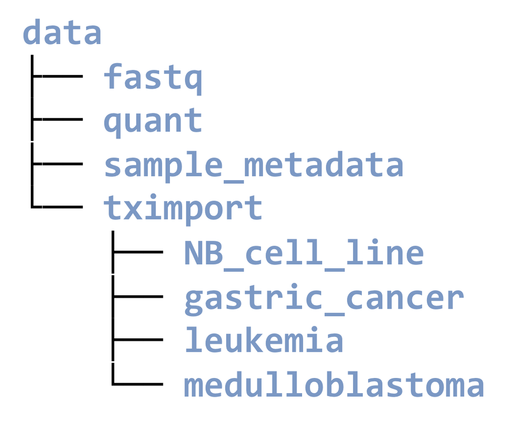

```r
project_structure <- file.path("diagrams", "project_structure.png")
knitr::include_graphics(project_structure)
```

An advantage of organizing the directories this way is that it makes it easy to adapt the tximport processing steps for the gastric cancer dataset to process the neuroblastoma cell line by changing the last argument to `file.path()`.

```r
# The path to the quant files for the gastric cancer dataset
file.path("data", "quant", "gastric_cancer")
# The path to the quant files for the neuroblastoma cell line dataset
file.path("data", "quant", "NB_cell_line")
```

For data types that have files on a *per sample basis* (FASTQ, quant), rather than for an entire dataset/experiment, the files for a sample are in a directory named based on a unique identifier for that sample.

```r
dir(file.path("data", "quant", "NB_cell_line"))
```

```
character(0)
```

## Filtering DESeq2 DGE results for downstream analysis

During the main session on differential expression analysis, we sorted results based on the Wald statistic. The Wald test is the hypothesis test for comparing two groups; it also produces the p-values in the results that are then corrected for multiple hypothesis testing via Benjamini-Hochberg (BH) adjustment (default settings).

> BH-adjusted p-values are often referred to as false discovery rates or FDR. For an explainer on FDR values, check out [this excellent video from StatQuest](https://www.youtube.com/watch?v=K8LQSvtjcEo).

In practice, we’re often interested in genes with low FDR values and the highest magnitude of log2 fold changes (LFC). (This is the rationale behind volcano plots like the one we made in the Intro to R and the Tidyverse module.)

### Load in results from neuroblastoma cell line

Yesterday, we saved the object returned by `DESeq2::DESeq()` as an RDS file.

```r
deseq_object_file <- file.path("results",
                               "NB_cell_line_DESeq_amplified_v_nonamplified.RDS")
deseq_object <- readr::read_rds(deseq_object_file)
```

We need to load in the `DESeq2` library and we’ll use the `%>%` operator later.

```r
library(DESeq2)
`%>%` <- dplyr::`%>%`
```

### Shrunken log2 foldchanges

There’s an additional step we can take to get more accurate log2 fold change estimates to use for visualization or ranking.

> We **highly recommend** taking a look at the resources we adapted this section from!
> - [Harvard Chan Bioinformatics Core (HBC). *DGE Analysis: Pairwise Comparisons (Wald Test).*](https://hbctraining.github.io/DGE_workshop_salmon/lessons/05_DGE_DESeq2_analysis2.html)
> - [Love, Anders, and Huber. *Analyzing RNA-seq data with DESeq2.*](https://bioconductor.org/packages/devel/bioc/vignettes/DESeq2/inst/doc/DESeq2.html#log-fold-change-shrinkage-for-visualization-and-ranking)

```r
# Look at the contrasts available
resultsNames(deseq_object)
```

```
[1] "Intercept"                        "Status_Amplified_vs_Nonamplified"
```

We compared the *MYCN* amplified cell lines to the non-amplified cell lines. Shrink the LFC for more accurate estimates.

```r
results_table_mycn <- results(deseq_object,
                              alpha = 0.05)
results_lfc <- lfcShrink(deseq_object,
                         coef = "Status_Amplified_vs_Nonamplified",
                         res = results_table_mycn)
```

[output not shown]

```r
results_lfc
```

```
log2 fold change (MAP): Status Amplified vs Nonamplified
Wald test p-value: Status Amplified vs Nonamplified
DataFrame with 37066 rows and 6 columns
                          baseMean     log2FoldChange             lfcSE                stat             pvalue
                         <numeric>          <numeric>         <numeric>           <numeric>          <numeric>
ENSG00000000003   1374.64407710417  0.675318412020197 0.287642610789615    2.35956417832813 0.0182964157873946
ENSG00000000005   2.50734211440614  0.432797019576775  0.35667708841965    1.24481618766113  0.213199324411805
ENSG00000000419   1889.77465231461 -0.178968487430894 0.209677443931002  -0.853345550545899  0.393467706920757
ENSG00000000457    1356.4820233146 -0.184685565972405 0.157325298346593   -1.17382936156313   0.24046338083167
ENSG00000000460   1726.46214626025 -0.147503682821317 0.199649764001378  -0.738697059833294  0.460090971532975
...                            ...                ...               ...                 ...                ...
ENSG00000285868    12.677069886512 -0.294369358301218 0.300438738903571  -0.979128902466494  0.327516292466265
ENSG00000285889   23.4281906430937  0.455768751753221 0.323280279443454    1.42129168239003   0.15523198056901
ENSG00000285976   1949.42688188834 0.0577857525568939 0.168066953677397   0.343839398823962  0.730967068710524
ENSG00000285978   13.5841070479241 -0.663906316444584 0.231178402623693   -2.87479494113498 0.0040428997360809
ENSG00000285980 0.0355695916808087 -0.237898460419886 0.153410863763733 -0.0376402671850649  0.969974502085329
                              padj
                         <numeric>
ENSG00000000003  0.119432454294938
ENSG00000000005  0.491619310276755
ENSG00000000419  0.668177233661488
ENSG00000000457  0.523970255656358
ENSG00000000460  0.718475549760461
...                            ...
ENSG00000285868  0.612146599885907
ENSG00000285889   0.41624509640095
ENSG00000285976  0.884941292017034
ENSG00000285978 0.0460103390246153
ENSG00000285980                 NA
```

Let’s say we wanted to filter based on log2 fold change *and* FDR before writing to file. You can use `dplyr::filter()` to filter based on the `log2FoldChange` and `padj` columns. Negative values in the `log2FoldChange` column will have lower expression in the Amplified group. If we did not take the absolute value of the `log2FoldChange` in our filtering step, we’d be missing out on those genes!

```r
results_lfc %>%
  data.frame() %>%
  tibble::rownames_to_column("Gene") %>%
  dplyr::filter(padj < 0.05, abs(log2FoldChange) > 0.585)  # ~1.5x change
```

| Gene | baseMean | log2FoldChange | lfcSE | stat | pvalue | padj |
| --- | --- | --- | --- | --- | --- | --- |
| ENSG00000001036 | 1.072783e+03 | -1.0011922 | 0.3403748 | -2.882876 | 3.940631e-03 | 4.523401e-02 |
| ENSG00000001460 | 3.464072e+02 | -1.0805144 | 0.2536449 | -4.246535 | 2.171017e-05 | 1.268261e-03 |
| ENSG00000001461 | 7.319534e+02 | -1.2651863 | 0.2776822 | -4.527657 | 5.964126e-06 | 5.095481e-04 |
| ENSG00000003056 | 5.796364e+03 | -0.7323567 | 0.2114839 | -3.459539 | 5.411002e-04 | 1.204881e-02 |
| ENSG00000003402 | 3.429488e+03 | -1.0110047 | 0.2753409 | -3.653834 | 2.583531e-04 | 7.319296e-03 |
| ENSG00000004776 | 1.725797e+01 | -0.8882897 | 0.2683873 | -3.300764 | 9.642186e-04 | 1.762547e-02 |
| ENSG00000004948 | 1.936526e+00 | -1.2638668 | 0.3470276 | -3.416109 | 6.352285e-04 | 1.337502e-02 |
| ENSG00000005020 | 1.047186e+02 | -1.0666130 | 0.3363803 | -3.112326 | 1.856196e-03 | 2.700252e-02 |
| ENSG00000005156 | 6.630079e+03 | 0.8558701 | 0.1623091 | 5.274929 | 1.328077e-07 | 3.073347e-05 |
| ENSG00000005238 | 5.453911e+02 | -1.5790038 | 0.2319417 | -6.787051 | 1.144484e-11 | 1.274764e-08 |

[output cut: 990 more lines]

### Volcano plot

We can make a volcano plot using a [Bioconductor](https://bioconductor.org/) package called [`EnhancedVolcano`](https://bioconductor.org/packages/release/bioc/html/EnhancedVolcano.html). Volcano plots provide information about the p-values or FDR (y-axis) and the log2 fold change (x-axis).

```r
# Here's how we install a Bioconductor package
BiocManager::install("EnhancedVolcano", update = FALSE)
```

`EnhancedVolcano::EnhancedVolcano` can take `DESeqResults` directly ([Quick Start Guide](https://github.com/kevinblighe/EnhancedVolcano#quick-start))

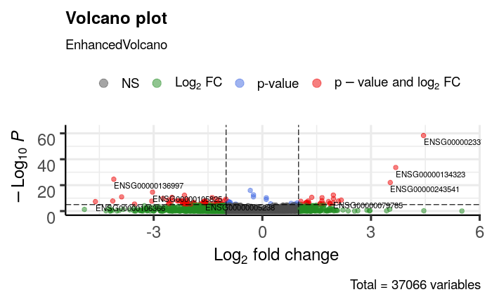

```r
EnhancedVolcano::EnhancedVolcano(results_lfc,
                                 lab = rownames(results_lfc),
                                 x = 'log2FoldChange',
                                 y = 'padj')
```